# Reproducible Research Peer Assessment 1

Bazza

### Loading and preprocessing the data

Code assumes the data have been downloaded and unzipped into the current working directory.  
The dataset was sourced from the web here: [Data set used in this analysis](https://d396qusza40orc.cloudfront.net/repdata%2Fdata%2Factivity.zip)  
The dataset was downloaded on 8 December 2014.

```r
inputData <- read.csv("activity.csv")
inputData$interval <- as.factor(inputData$interval)
inputData$date <- as.Date(inputData$date, format="%Y-%m-%d")
head(inputData)
```

```
##   steps       date interval
## 1    NA 2012-10-01        0
## 2    NA 2012-10-01        5
## 3    NA 2012-10-01       10
## 4    NA 2012-10-01       15
## 5    NA 2012-10-01       20
## 6    NA 2012-10-01       25
```

### What is mean total number of steps taken per day?

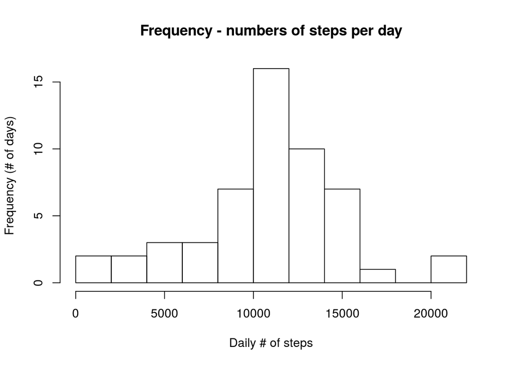

```r
dailySteps <- aggregate(steps ~ date, sum, data=inputData, na.rm=TRUE)
hist(dailySteps$steps, breaks = 12, xlab = "Daily # of steps", ylab = "Frequency (# of days)", main = "Frequency - numbers of steps per day")
```

```r
theMean <- round(mean(dailySteps$steps, na.rm=TRUE))
theMedian <- round(median(dailySteps$steps, na.rm=TRUE))
```

The mean number of steps taken per day is:

```
## [1] 10766
```

The median number of steps taken per day is:

```
## [1] 10765
```

### What is the average daily activity pattern?

Plot code and plot of average daily activity pattern:

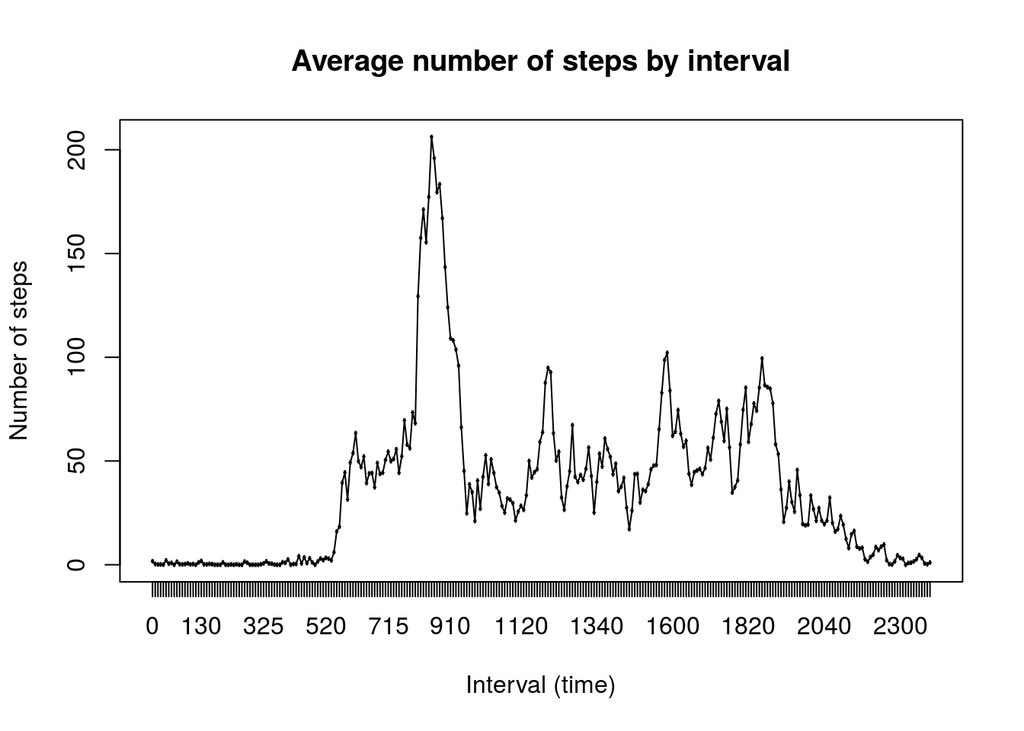

```r
#use base plotting system to draw a line chart
intervalSteps <- aggregate(steps ~ interval, mean, data=inputData, na.rm=TRUE)
par(pch=21, col="black")
plot(intervalSteps$interval, intervalSteps$steps, xlab = "Interval (time)", ylab = "Number of steps", main = "Average number of steps by interval", type = "n")
lines(intervalSteps$interval, intervalSteps$steps, type = "l")
```

The highest number of steps occurs during interval 835:

```r
mostSteps <- subset(intervalSteps, steps==max(steps))
mostStepsTime <- mostSteps[1]$interval
mostStepsTime
```

```
## [1] 835
## 288 Levels: 0 5 10 15 20 25 30 35 40 45 50 55 100 105 110 115 120 ... 2355
```

### Imputing missing values

There are 2304 missing values among the 17568 observations:

```r
sum(is.na(inputData$steps))
```

```
## [1] 2304
```

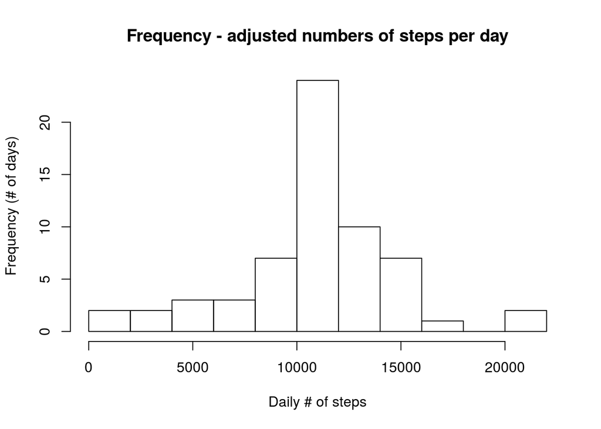

```r
# add column of imputed data
adjustedData <- inputData
imputeMean <- function(x) replace(x, is.na(x), mean(x, na.rm = TRUE)) # from stackoverflow 17297897
newCol <- imputeMean(adjustedData$steps)
adjustedData["imputedSteps"] <- newCol

#identical to earlier process, with imputed data
dailyAdjustedSteps <- aggregate(imputedSteps ~ date, sum, data=adjustedData, na.rm=TRUE)
hist(dailyAdjustedSteps$imputedSteps, breaks = 12, xlab = "Daily # of steps", ylab = "Frequency (# of days)", main = "Frequency - adjusted numbers of steps per day")
```

```r
theAdjustedMean <- round(mean(dailyAdjustedSteps$imputedSteps, na.rm=TRUE))
theAdjustedMedian <- round(median(dailyAdjustedSteps$imputedSteps, na.rm=TRUE))
```

The mean number of steps taken per day (after replacing all NA) is now:

```
## [1] 10766
```

The median number of steps taken per day (after replacing all NA) is now:

```
## [1] 10766
```

### Are there differences in activity patterns between weekdays and weekends?

I used the approach supplied by fellow student Renaud Dufour, in December 2014 class discussion thread #37, to create a new column labelling all observations as either weekday or weekend. Then I plotted the weekday and weekend data separately. A simple visual comparison of the activity plots shows that the answer to this question is **YES**. Apparently this population is composed mainly of sedentary (office?) workers who sleep later and enjoy movement throughout the day on weekends.

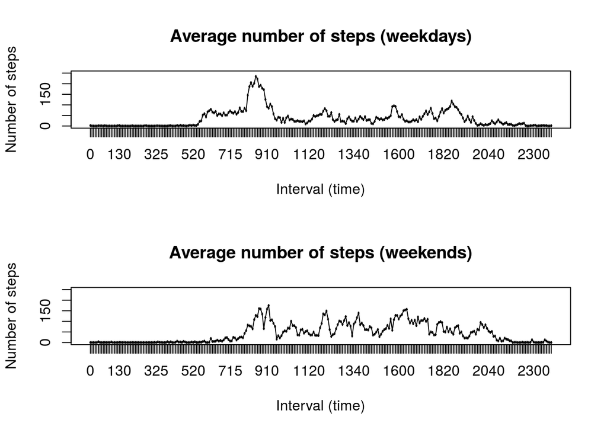

```r
# new column for day type
library(lubridate)
adjustedData[, "dayType"] <- as.Date(NA)
adjustedData$dayType <- factor(ifelse(wday(adjustedData$date) %in% c(1,7), "weekend", "weekday"))
# one DF for weekday, another for weekend
weekdayData <- subset(adjustedData, dayType == "weekday")
weekendData <- subset(adjustedData, dayType == "weekend")
#plot two line graphs using basic plotting system
par(mfrow=c(2,1))
par(pch=21, col="black")
intervalSteps <- aggregate(steps ~ interval, mean, data=weekdayData, na.rm=TRUE)
plot(intervalSteps$interval, intervalSteps$steps, ylim=c(0,250), xlab = "Interval (time)", ylab = "Number of steps", main = "Average number of steps (weekdays)", type = "n")
lines(intervalSteps$interval, intervalSteps$steps, type = "l")
intervalSteps <- aggregate(steps ~ interval, mean, data=weekendData, na.rm=TRUE)
plot(intervalSteps$interval, intervalSteps$steps, ylim=c(0,250), xlab = "Interval (time)", ylab = "Number of steps", main = "Average number of steps (weekends)", type = "n")
lines(intervalSteps$interval, intervalSteps$steps, type = "l")
```